# Final Project Demo

Hope Mumme

4/20/2022

## Final Project Demo (BMI 585)

Hope Mumme

Libraries and Data

```r
library(Seurat, verbose = F)
library(ArchR, verbose = F)
library(dplyr, verbose = F)
library(fgsea, verbose = F)

load("demo.RData")
```

### Data Pre-Processing

Build merged seurat object for CITE-seq

```r
# build CITE-seq objects - MPAL
rna_m1 = "../Data/GSM4138879_scRNA_MPAL1_T2.rds.gz"
adt_m1 = "../Data/GSM4138879_scADT_MPAL1_T2.rds.gz"
m1 = buildCITE(rna_m1, adt_m1)

rna_m2 = "../Data/GSM4138880_scRNA_MPAL2_T1.rds.gz"
adt_m2 = "../Data/GSM4138880_scADT_MPAL2_T1.rds.gz"
m2 = buildCITE(rna_m2, adt_m2)

# build CITE-seq objects - Control
rna_c1 = "../Data/GSM4138872_scRNA_BMMC_D1T1.rds.gz"
adt_c1 = "../Data/GSM4138872_scADT_BMMC_D1T1.rds.gz"
c1 = buildCITE(rna_c1, adt_c1)

rna_c2 = "../Data/GSM4138873_scRNA_BMMC_D1T2.rds.gz"
adt_c2 = "../Data/GSM4138873_scADT_BMMC_D1T2.rds.gz"
c2 = buildCITE(rna_c2, adt_c2)

# merge CITE-seq objects
obj = merge(m1, y=c(m2,c1,c2), add.cell.ids=c("M1","M2","C1","C2"), project = "demo")
```

Build merged ArchR object for ATAC-seq

```r
set.seed(1)
ArchR::addArchRThreads(threads = 16)
ArchR::addArchRGenome("hg19")

m1Files = c("../Data/GSM4138898_scATAC_MPAL1_T1.fragments.tsv.gz","../Data/GSM4138899_scATAC_MPAL1_T2.fragments.tsv.gz")
m2Files = c("../Data/GSM4138900_scATAC_MPAL2_T1.fragments.tsv.gz","../Data/GSM4138901_scATAC_MPAL2_T2.fragments.tsv.gz")
c1Files = "../Data/GSM4138888_scATAC_BMMC_D5T1.fragments.tsv.gz"
c2Files = "../Data/GSM4138889_scATAC_BMMC_D6T1.fragments.tsv.gz"

inputFiles = c(m1Files,m2Files,c1Files,c2Files)
names(inputFiles) = c("m1-1","m1-2","m2-1","m2-2","c1","c2")

ArrowFiles <- ArchR::createArrowFiles(
  inputFiles = inputFiles,
  sampleNames = names(inputFiles),
  filterTSS = 4,
  filterFrags = 1000,
  addTileMat = TRUE,
  addGeneScoreMat = TRUE
)

doubScores <- ArchR::addDoubletScores(
  input = ArrowFiles,
  k = 10, #Refers to how many cells near a "pseudo-doublet" to count.
  knnMethod = "UMAP", #Refers to the embedding to use for nearest neighbor search.
  LSIMethod = 1
)

proj <- ArchR::ArchRProject(
  ArrowFiles = ArrowFiles,
  outputDirectory = "arrowProj_demo",
  copyArrows = F
)

ArchR::getAvailableMatrices(proj)
```

### Normalization and Clustering

RNA/ADT normalization and clustering

```r
Seurat::DefaultAssay(obj) = "RNA"
obj = Seurat::NormalizeData(obj, verbose = F)
obj = Seurat::FindVariableFeatures(obj, verbose = F)
obj = Seurat::ScaleData(obj, verbose = F)
obj = Seurat::NormalizeData(obj, normalization.method = "CLR", margin = 2, assay = "ADT", verbose = F)
obj = Seurat::ScaleData(obj, assay = "ADT", verbose = F)

Seurat::DefaultAssay(obj) = "RNA"
obj = Seurat::RunPCA(obj, verbose = F)
obj = Seurat::FindNeighbors(obj, verbose = F)
obj = Seurat::FindClusters(obj, verbose = F)
obj = Seurat::RunUMAP(obj, dims = 1:10, verbose = F)

# label groups
obj$group = "T-MPAL"
obj$group[obj$orig.ident == "BMMC"] = "Control"
```

RNA/ADT UMAPs

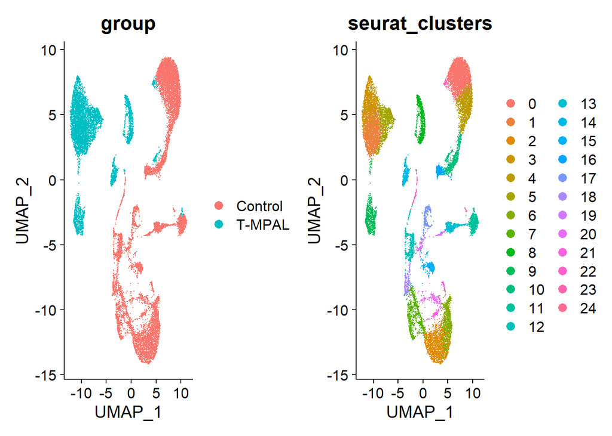

```r
p1 = Seurat::DimPlot(obj, group.by = "group")
p2 = Seurat::DimPlot(obj, group.by = "seurat_clusters")
p1 + p2
```

RNA/ADT protein/gene expression

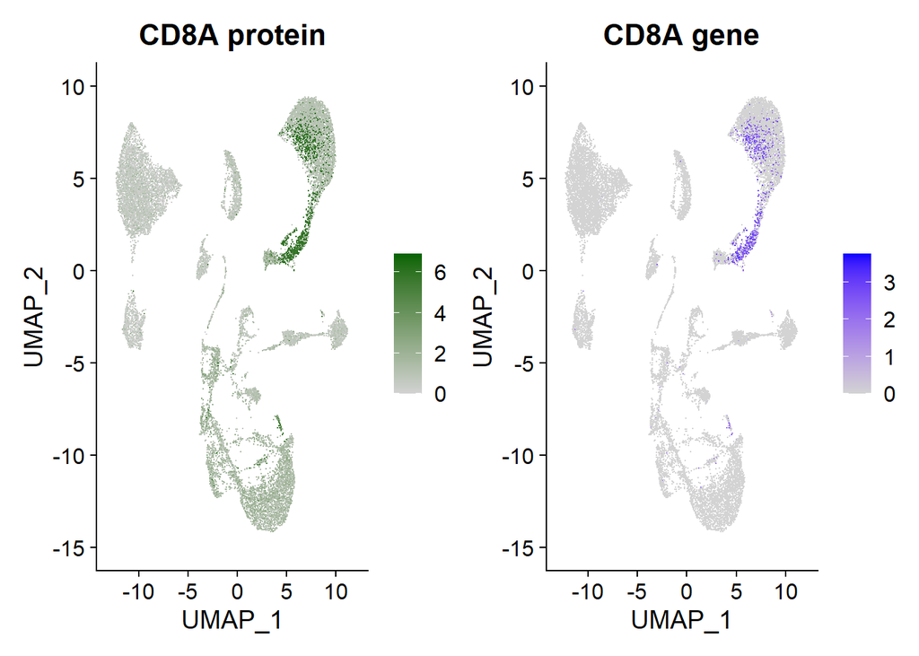

```r
Seurat::DefaultAssay(obj) = "ADT"
p1 = Seurat::FeaturePlot(obj, features = "CD8A" ,cols = c("lightgrey", "darkgreen")) + ggplot2::ggtitle("CD8A protein")
Seurat::DefaultAssay(obj) = "RNA"
p2 = Seurat::FeaturePlot(obj, features = "CD8A") + ggplot2::ggtitle("CD8A gene")
p1 | p2
```

ATAC filtering

```r
proj <- ArchR::filterDoublets(proj)
proj <- ArchR::addIterativeLSI(ArchRProj = proj, useMatrix = "TileMatrix", name = "IterativeLSI")

proj$group = "T-MPAL"
proj$group[proj$Sample == "c1" | proj$Sample == "c2"] = "Control"
```

### Differential Expression - RNA / ATAC

```r
Seurat::Idents(obj) = "group"
rnaMarkers = Seurat::FindMarkers(obj, ident.1 = "T-MPAL", ident.2 = "Control")
Seurat::DefaultAssay(obj) = "ADT"
adtMarkers = Seurat::FindMarkers(obj, ident.1 = "T-MPAL", ident.2 = "Control")
Seurat::DefaultAssay(obj) = "RNA"

atacDE = ArchR::getMarkerFeatures(proj, groupBy = "group", useMatrix = "GeneScoreMatrix")
atacMarkers = ArchR::getMarkers(atacDE, cutOff = "FDR <= 0.05 & abs(Log2FC) >= 0.25")
head(atacMarkers[["T-MPAL"]])
```

### TF Database

[ENCODE Transcription Factor Targets Dataset](https://maayanlab.cloud/Harmonizome/dataset/ENCODE+Transcription+Factor+Targets) used to identify TF-target associations in our datasets.

```r
db = qusage::read.gmt("../Data/gene_set_library_crisp.gmt")
```

### (1) identify highly expressed TFs in T-MPAL compared to Control

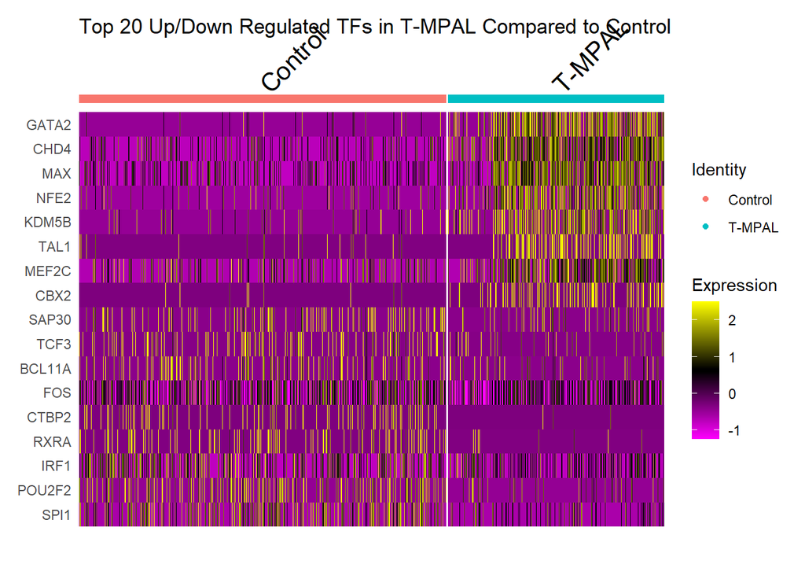

```r
Seurat::DefaultAssay(obj) = "RNA"
Seurat::Idents(obj) = "group"
topTFs = getTFs(obj, rnaMarkers, db, num = 20)
Seurat::DoHeatmap(obj, features = unlist(topTFs), group.by = "group", slot = "scale.data") + ggtitle("Top 20 Up/Down Regulated TFs in T-MPAL Compared to Control")
```

### (2) Identify active/non-active TFs in T-MPAL

First, we need to extract the targets for the up-regulated TFs in our dataset, then we calculate gene set enrichment of TF target genes in the ATAC data.

```r
# identify all up-regulated TFs in T-MPAL
tfs = getTFs(obj, rnaMarkers, db, num = "all")[["T-MPAL"]]

# filter TF database to only include these TFs
db.filt = db[names(db) %in% tfs]

# calculate gene set enrichment of the TF targets in our ATAC data
en = suppressWarnings(tfEnrichment(atacMarkers[["T-MPAL"]], db.filt))
head(en)
```

```
##    pathway         pval         padj   log2err         ES        NES size
## 1:    ATF3 6.197194e-36 2.602822e-35 1.5565442 -0.2618345 -2.0803091 1977
## 2:    BATF 1.199077e-26 4.196771e-26 1.3422338 -0.2846389 -2.2717257 1085
## 3:    BDP1 1.071429e-01 1.406250e-01 0.2279872 -0.3139491 -1.3463933   29
## 4:    CBX2 3.750000e-01 4.632353e-01 0.1766943 -0.1403863 -1.0274972  406
## 5:   CEBPZ 6.486486e-01 7.567568e-01 0.1017139 -0.1465165 -0.9197227  161
## 6:    CHD1           NA           NA        NA -0.1582863         NA 4806
##                                           leadingEdge
## 1: MIR592,HOXA9,HIST2H3D,CEBPD,ZNF503-AS2,ST7-OT4,...
## 2:  HIST2H3D,FOXD4,HLA-L,NSUN5P2,MIR4666A,ST7-OT4,...
## 3:            FANK1,MLKL,ZNF718,DPP9,ZNF595,PSMC3,...
## 4:         FAM71F2,HLA-L,CPNE6,OLFML1,HEY2,LILRB4,...
## 5:            SYDE2,EGLN1,DCUN1D4,SLC2A8,CA2,LCA5,...
## 6:    MIR196B,MIR592,HIST2H3D,FOXD4,FAM71F2,HOXA5,...
```

```r
# identify positively and negatively enriched "pathways" or TFs
library(dplyr)
posTFs = en %>% filter(NES > 0 & padj < 0.05) %>% select(pathway,NES)
posTFs
```

```
## Empty data.table (0 rows and 2 cols): pathway,NES
```

```r
negTFs = en %>% filter(NES < 0 & padj < 0.05) %>% select(pathway,NES)
negTFs
```

```
##     pathway       NES
##  1:    ATF3 -2.080309
##  2:    BATF -2.271726
##  3:    CHD4 -1.310772
##  4:    CUX1 -2.166380
##  5:    FLI1 -1.982374
##  6:   KDM1A -1.658914
##  7:    MAFF -1.457242
##  8:   MEF2C -1.680824
##  9:    NFE2 -2.225914
## 10: SMARCC1 -1.646512
## 11: SMARCC2 -1.835558
## 12:  STAT5A -2.560982
## 13:    TAL1 -1.642121
## 14:  WRNIP1 -2.597094
## 15: ZKSCAN1 -2.376502
```

We can plot specific TF gene set enrichment using fgsea functions

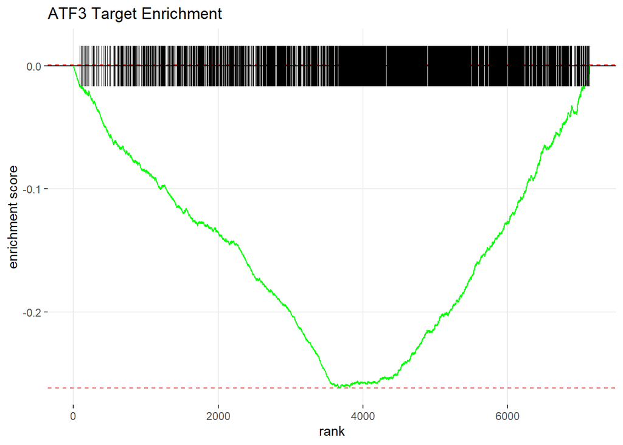

```r
plotEn(atacMarkers[["T-MPAL"]], db.filt, "ATF3")
```

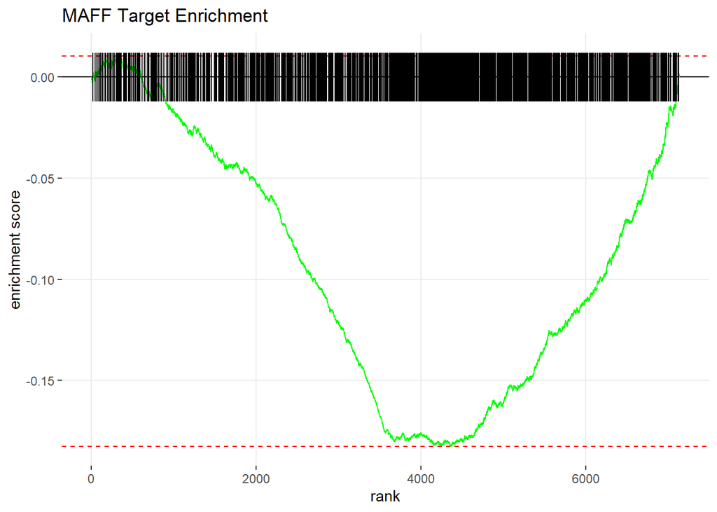

```r
plotEn(atacMarkers[["T-MPAL"]], db.filt, "MAFF")
```

### (3) Identify active/non-active target proteins in T-MPAL

All the surface proteins were found to be down-regulated in T-MPAL compared to the healthy Control. This makes sense because most of the proteins in the dataset are immune cell markers, which are more likely to be higher expressed in the healthy control, which contains all immune cells and no cancerous cells.

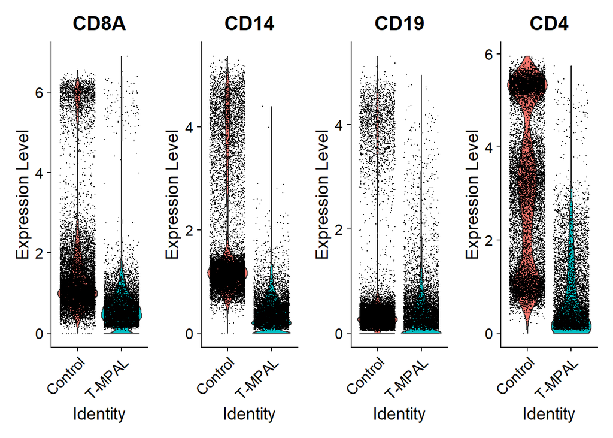

```r
# identify TFs with protein targets in the dataset
protein_targets = getProteins(adtMarkers, db.filt)

# plot violin plots for each target
Seurat::DefaultAssay(obj) = "ADT"
Seurat::VlnPlot(obj, features = unique(protein_targets$target), group.by = "group", pt.size = 0.01, ncol = 4)
```

```r
# print TFs for each found target
for (gene in unique(protein_targets$target)) {
  print(gene)
  print(protein_targets$TF[protein_targets$target == gene])
  print("--------")
}
```

```
## [1] "CD8A"
##  [1] "ATF3"    "CBX2"    "CHD1"    "CHD2"    "CUX1"    "ELF1"    "GATA2"
##  [8] "GTF2F1"  "HDAC2"   "HMGN3"   "KDM4A"   "MAFF"    "MAX"     "MYC"
## [15] "REST"    "SMC3"    "STAT5A"  "TAL1"    "TBL1XR1" "WRNIP1"  "ZKSCAN1"
## [22] "ZMIZ1"
## [1] "--------"
## [1] "CD14"
##  [1] "CHD1"    "ELF1"    "HDAC2"   "MAFF"    "MAX"     "MYC"     "REST"
##  [8] "SMC3"    "STAT3"   "TAL1"    "TBL1XR1" "WRNIP1"
## [1] "--------"
## [1] "CD19"
##  [1] "CHD1"    "CHD2"    "CUX1"    "ELF1"    "HDAC2"   "KDM5B"   "MAX"
##  [8] "MYC"     "REST"    "SMC3"    "STAT5A"  "TAL1"    "TBL1XR1" "WRNIP1"
## [15] "ZMIZ1"
## [1] "--------"
## [1] "CD4"
## [1] "CHD1"  "KDM5A" "KDM5B" "MAFF"  "MAX"   "MYC"   "REST"
## [1] "--------"
```

```r
# identify TFs in db.filt that have targets in proteins
tf_step3 = NULL
for (tf in names(db.filt)) {
  if (any(unique(protein_targets$target) %in% db.filt[[tf]])) {
    tf_step3 = c(tf_step3, tf)
  }
}
tf_step3
```

```
##  [1] "ATF3"    "CBX2"    "CHD1"    "CHD2"    "CUX1"    "ELF1"    "GATA2"
##  [8] "GTF2F1"  "HDAC2"   "HMGN3"   "KDM4A"   "KDM5A"   "KDM5B"   "MAFF"
## [15] "MAX"     "MYC"     "REST"    "SMC3"    "STAT3"   "STAT5A"  "TAL1"
## [22] "TBL1XR1" "WRNIP1"  "ZKSCAN1" "ZMIZ1"
```

### (4) Identify active/non-active estimated target proteins in T-MPAL

If we assume that each cell contains a constant scaling factor between gene to protein expression, we can estimate the protein expression of the missing proteins in our dataset.

We will calculate the scaling factor as the average factor for the known proteins.

Assuming the formula approximates the relationship between gene and protein expression, $exp_{rna} = exp_{protein} * x$ , we can calculate the $x$ scaling factor using the relationship for known proteins.

```r
Seurat::DefaultAssay(obj) = "RNA"
rna = Seurat::GetAssayData(obj, slot = "counts")
x = getScale(obj, "group") # get scale for each group
```

```
## [1] "Calculating scale factor for ident T-MPAL ..."
## [1] "Calculating scale factor for ident Control ..."
```

```r
x
```

```
##      T-MPAL     Control
## 0.001462525 0.001840052
```

```r
est = estProtein(x, obj, db.filt, "ATF3", ident = "group")
head(est)
```

```
##     target   rna.exp e.protein  ident
## 1     ATG3 1.1492473  785.7968 T-MPAL
## 2 ATP6V0D1 0.5367960  367.0338 T-MPAL
## 3     STK4 3.4895239 2385.9588 T-MPAL
## 4    TRNT1 0.4694748  321.0029 T-MPAL
## 5    TRRAP 0.1916700  131.0542 T-MPAL
## 6   LRPAP1 1.5669594 1071.4071 T-MPAL
```

Generate barplot for TF of interest and use t.test or ANOVA to determine if there is significant difference between the groups.

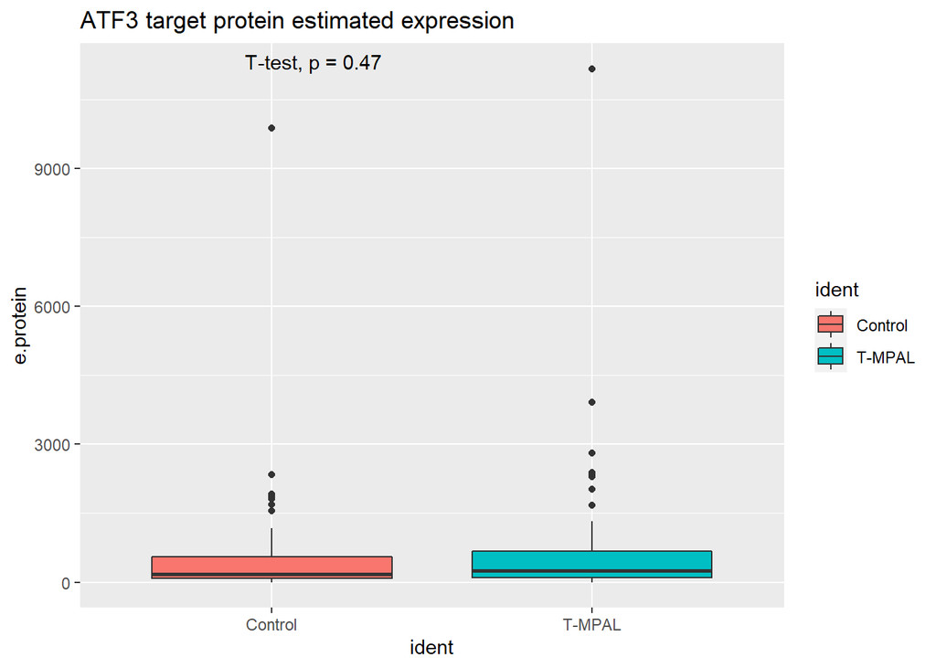

```r
tfBar(est, "ATF3")
```

Examine each TF after step 3 and determine if the estimated target genes are up/down regulated

```r
tf_step4 = data.frame(tf = names(db.filt), high = NA, pval = NA)
plots = list()
i = 1
for (tf in names(db.filt)) {
  est_tf = suppressWarnings(estProtein(x, obj, db.filt, tf, ident = "group"))
  avg_TMPAL = mean(est_tf$e.protein[est_tf$ident == "T-MPAL"])
  avg_Con = mean(est_tf$e.protein[est_tf$ident == "Control"])
  if (avg_TMPAL > avg_Con) {
    tf_step4$high[tf_step4$tf == tf] = "T-MPAL"
  } else {
    tf_step4$high[tf_step4$tf == tf] = "Control"
  }
  tf_step4$pval[tf_step4$tf == tf] = t.test(est_tf$e.protein[est_tf$ident == "T-MPAL"],est_tf$e.protein[est_tf$ident == "Control"])$p.value
  if (tf_step4$pval[tf_step4$tf == tf] < 0.05) {
    plots[[i]] = tfBar(est_tf, tf)
    i = i + 1
  }
}

write.table(tf_step4, sep = "\t", file = "demo_predictedProtein_tfs.txt")
```

### TF Patterns

Identify transcription factors that meet the following requirements: (1) up-regulated in T-MPAL compared to control (2) have higher enriched targets in T-MPAL versus control (3) have target proteins active in T-MPAL versus control (4) estimated protein targets are significantly higher in T-MPAL versus control

This dataset does not have any TFs that meet these conditions.